# Structural Divergence Analysis

Maria Laura Marcos, Julian Echave

# Introduction

We study the evolutionary divergence of proteins using the LF-ENM and comparing simulated mutants with experimental data.

In this case we studied the alpha_amylase family. We used the ENM ANM with R0 = 10 to generate mutants. We used as reference for the ENM the protein with pdb code 1g94a. The active/functional sites of the reference are:

```
##    active.site.index                         description
## 1                 88           Ca metal ion-binding site
## 2                 89              substrate-binding site
## 3                135           Ca metal ion-binding site
## 4                144           Ca metal ion-binding site
## 5                172              substrate-binding site
## 6                174              substrate-binding site
## 7                178           Ca metal ion-binding site
## 8                200          proton donor - active site
## 9                207              substrate-binding site
## 10               262             Chloride - binding site
## 11               264 Transition state stabilizer - site
## 12               269              substrate-binding site
## 13               300             Chloride - binding site
```

We simulated 10 mutants of this reference for each protein of the family. The alpha_amylase family is of the type alpga beta barrel and consists of the following proteins:

```
##  [1] "1hx0a" "1smd"  "1jae"  "1bag"  "1smaa" "1bvza" "1uok"  "2aaa"
##  [9] "7taa"  "1d3ca" "1ciu"  "1cyg"  "1hvxa" "1vjs"  "1gcya" "1avaa"
## [17] "1ehaa" "1bf2"  "1g5aa"
```

# Structural divergence along sites

Here we study how structural divergence varies from site to site. We compare simulated data with empirical data.

### Mean z.RSD vs site

To measure structural divergence we use z.RSD profiles, which are the best for most families.

The following plot compares the mean z.RSD profiles, including standard errors (with .999 confidence level for the mean) *Warning: the effective number of data should be smaller than the actual data, especially for the experimental dataset because of several factors. We need to deal with this for quantitative analysis. Probably we’ll need to use bootstrapping to calculate standard errors non-parametrically*

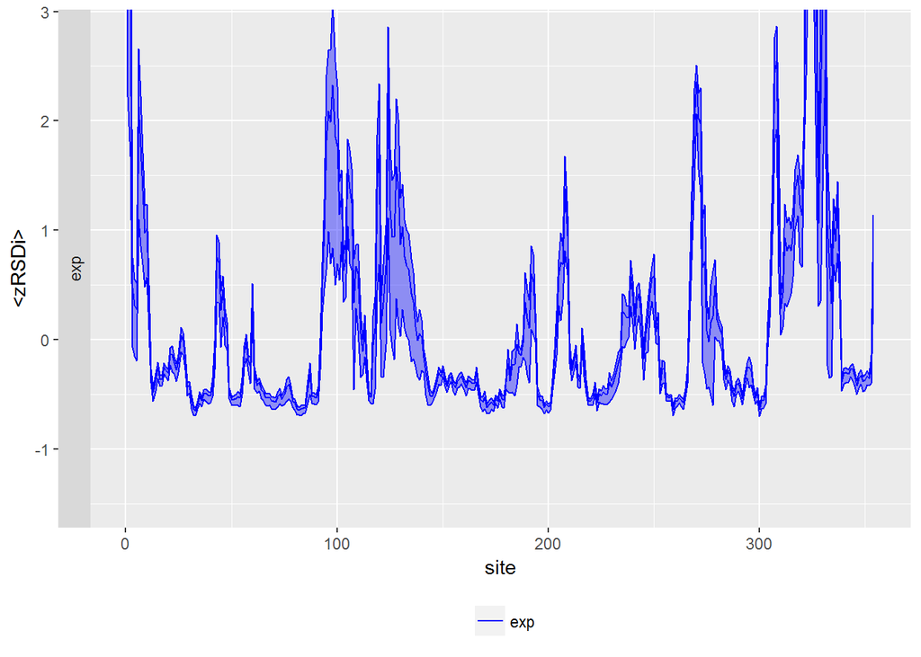

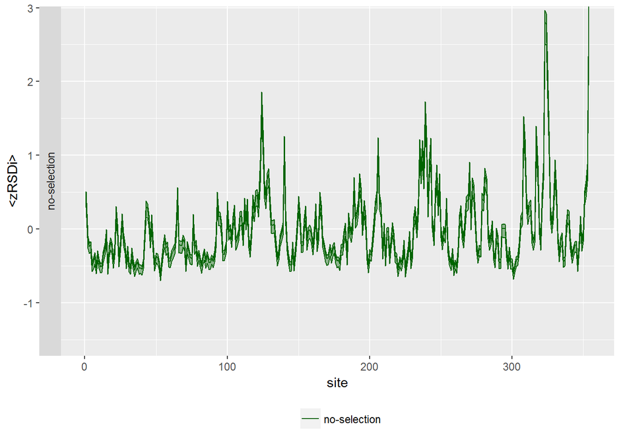

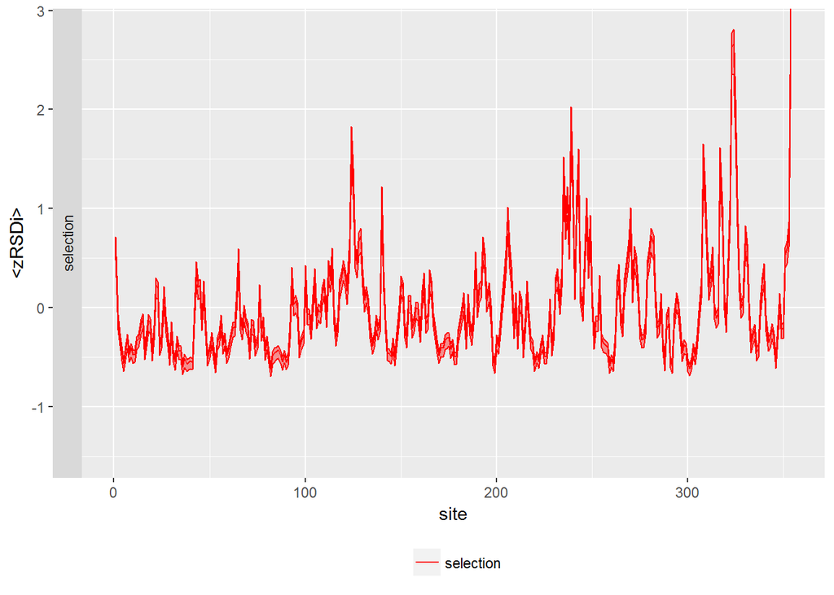

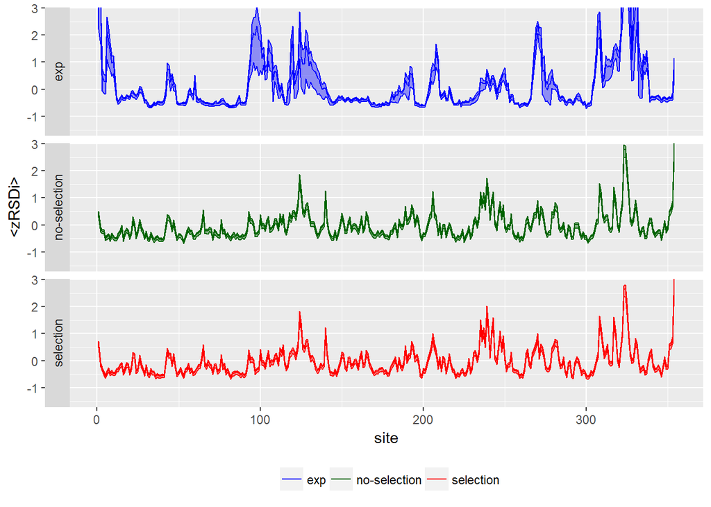

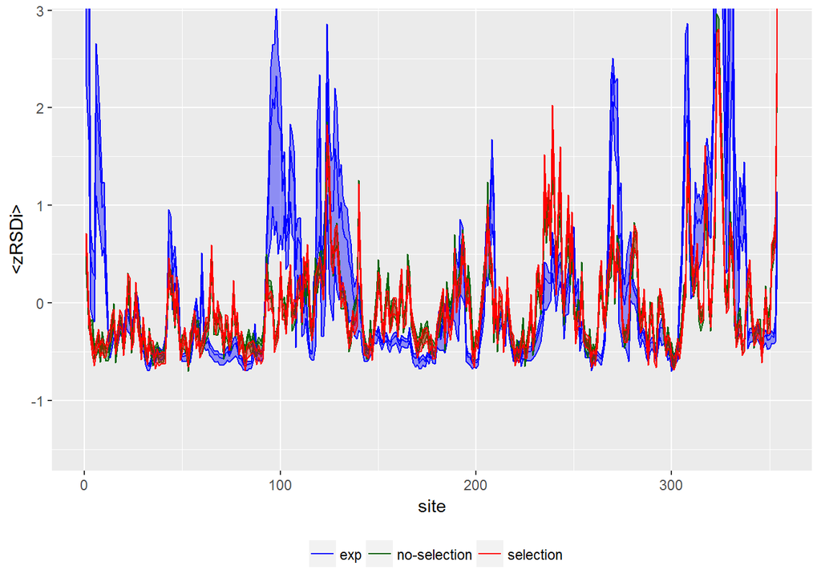

### Correlation between profiles

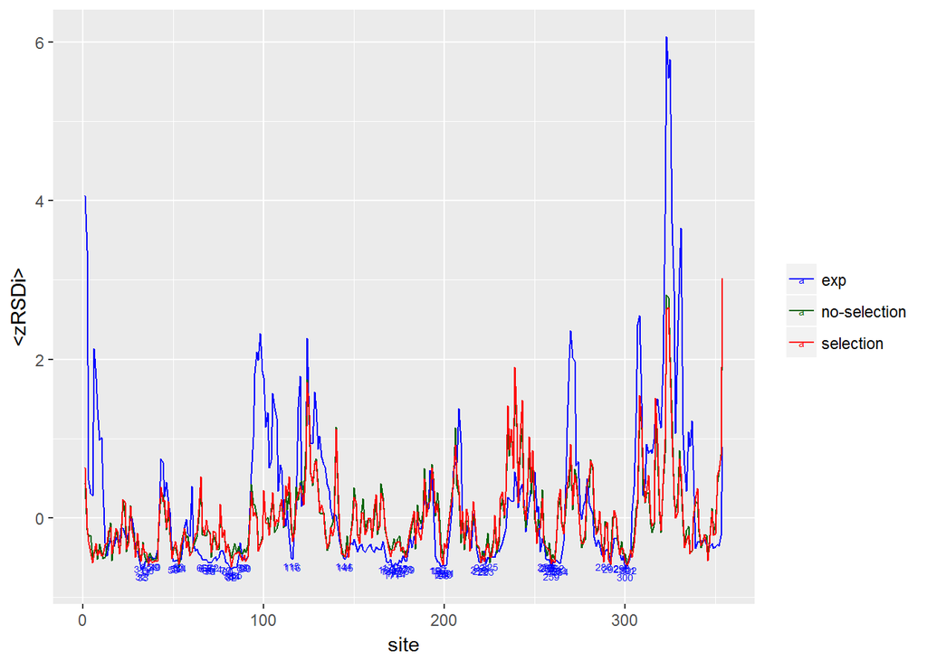

Correlation between profiles

| comparison | R |
| --- | --- |
| exp vs no-selection | 0.61 |
| exp vs selection | 0.59 |
| no-selection vs selection | 0.98 |

### Comparison between profiles

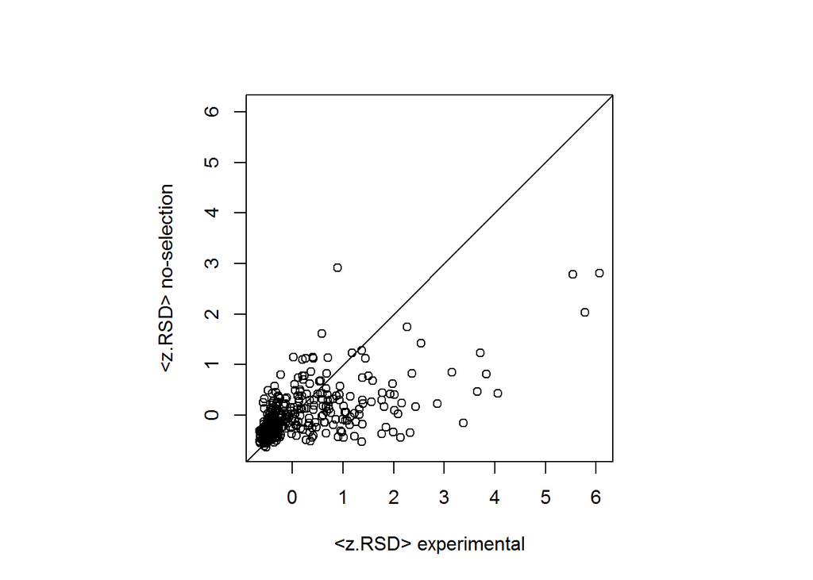

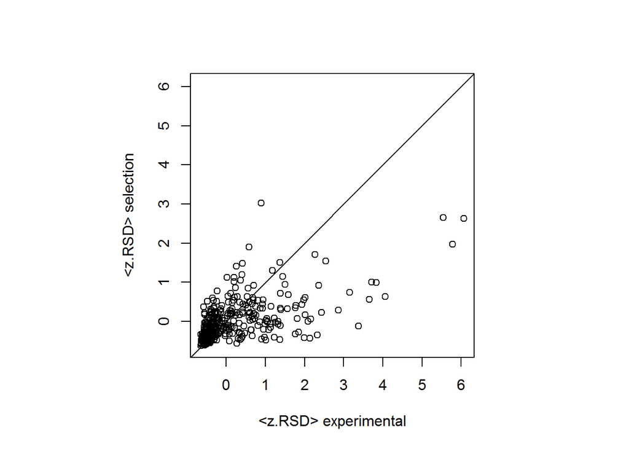

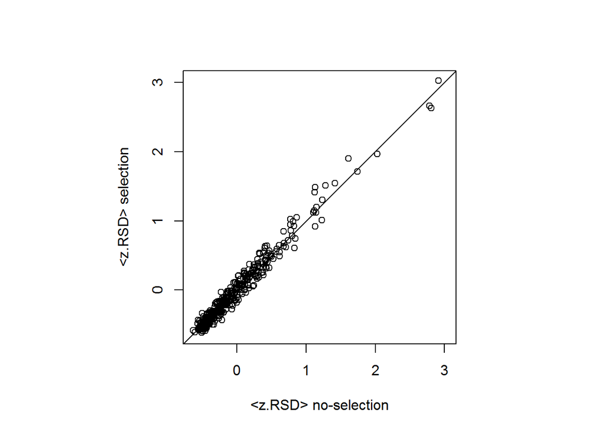

### Distances to the active sites

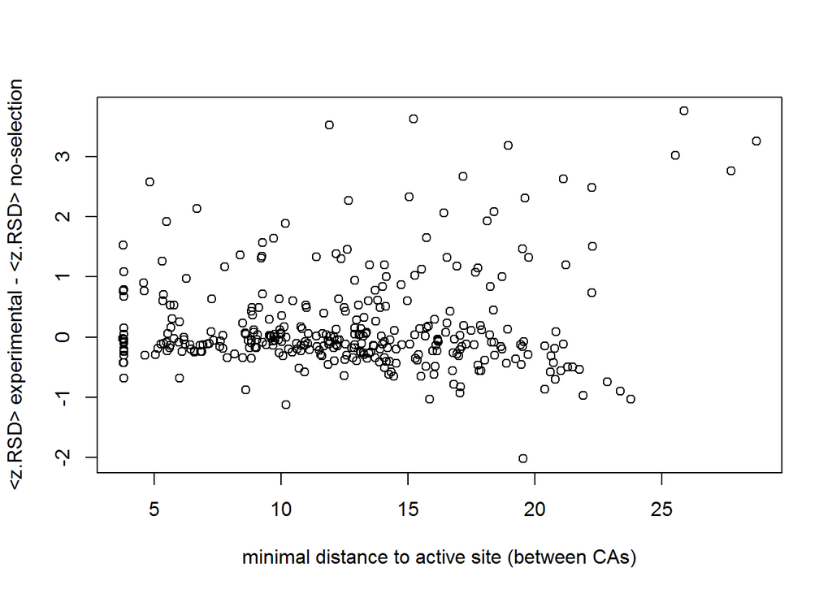

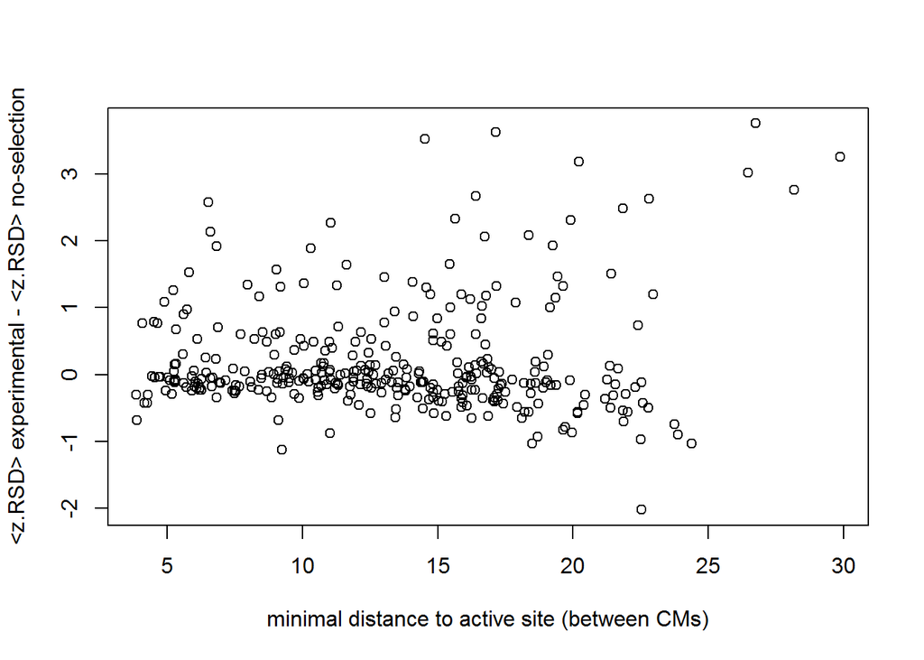

Correlation between differences in profiles and the minimal distance to the active site

| comparison | R |
| --- | --- |
| (exp - no-selection) vs min.da.CA | 0.11 |
| (exp - no-selection) vs min.da.CM | 0.09 |

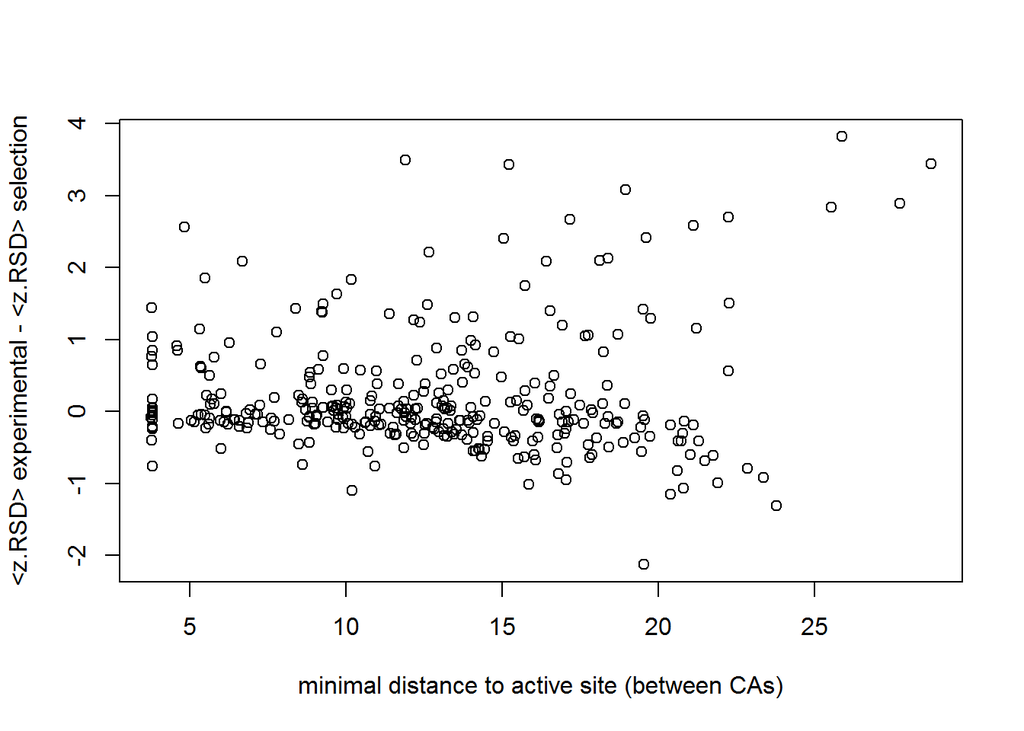

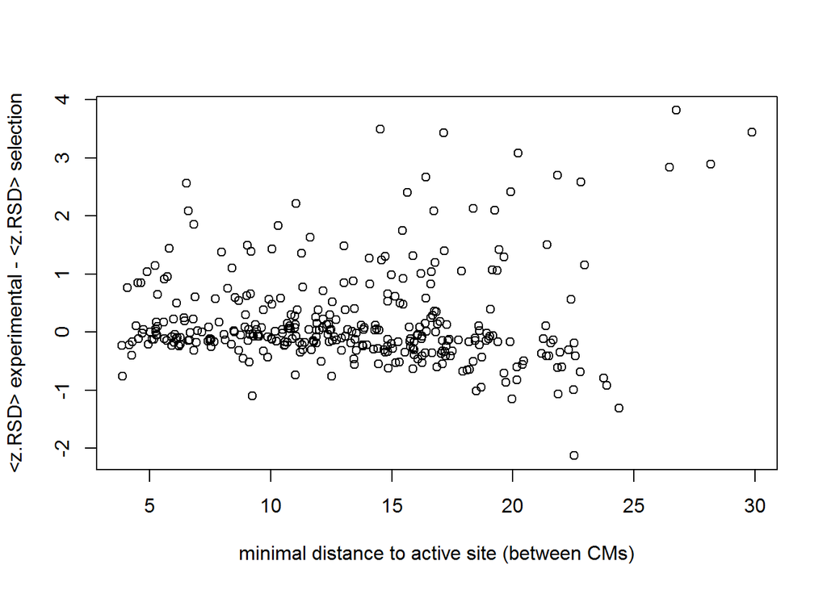

Correlation between differences in profiles and the minimal distance to the active site

| comparison | R |
| --- | --- |
| (exp - selection) vs min.da.CA | 0.09 |
| (exp - selection) vs min.da.CM | 0.07 |

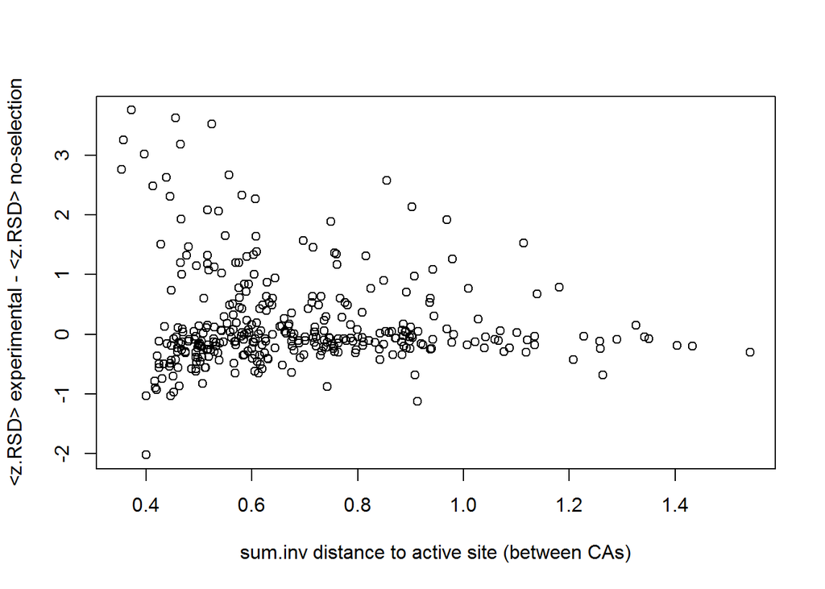

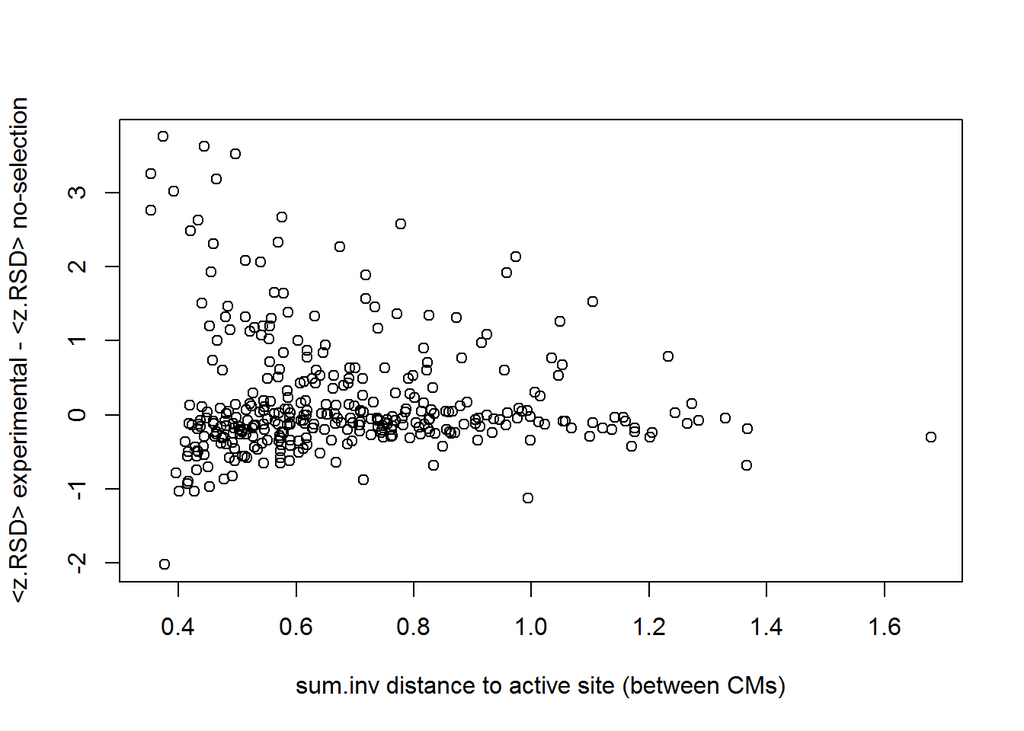

Correlation between differences in profiles and the sum.inv distance to the active site

| comparison | R |
| --- | --- |
| (exp - no-selection) vs sum.inv.da.CA | -0.10 |
| (exp - no-selection) vs sum.inv.da.CM | -0.09 |

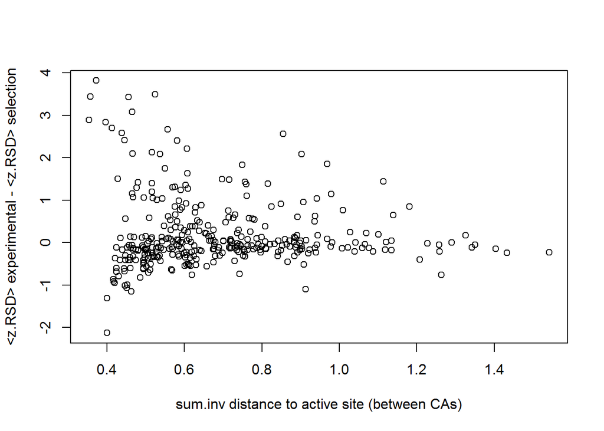

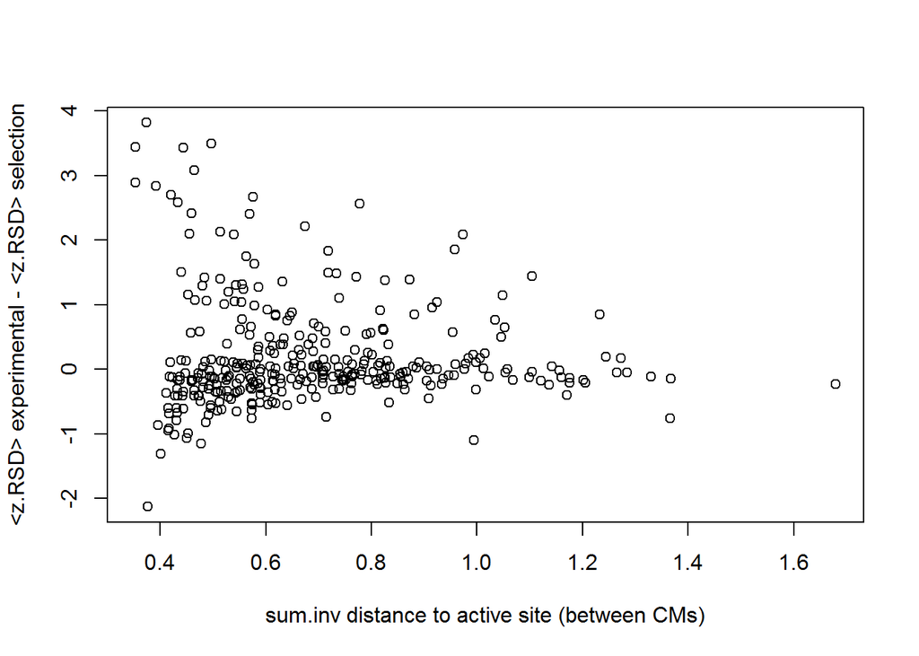

Correlation between differences in profiles and the sum.inv distance to the active site

| comparison | R |
| --- | --- |
| (exp - selection) vs sum.inv.da.CA | -0.08 |
| (exp - selection) vs sum.inv.da.CM | -0.07 |

Correlation between CN and the minimal distance to the active site

| comparison | R |
| --- | --- |
| CN vs min.da.CA | -0.46 |
| CN vs min.da.CM | -0.46 |

Correlation between CN and the sum.inv distance to the active site

| comparison | R |
| --- | --- |
| CN vs sum.inv.da.CA | 0.40 |
| CN vs sum.inv.da.CM | 0.38 |